# Set_19 Bioassay

Alexander Williams

2024-11-19

Bioassay is to measure LD50, point of lethal dose 50% of time. More generally, we want to find the point where 50% of the time, that dose will get a response.

we have dose values, and probability of response. Can we find curve that relates them? There’s only one variable, but we need to find the best link function. Once we have the best link function, we need the confidence interval on where the LD50 is

```r
## Log Dose CS2
dose<-c(1.6907, 1.7242,1.7552,1.7842,1.8113,1.8369,1.8610,1.8839)
## the number of insects killed
y<-c(6,13,18,28,52,53,61,60)
## the number of insects total
m<-c(59,60,62,56,63,59,62,60)
bioassay<-data.frame(dose=dose,y=y,m=m,prop=round(y/m,2))
kable(bioassay, caption = 'Dose-Response for Beetles exposed to CS2',align='l')
```

Dose-Response for Beetles exposed to CS2

| dose | y | m | prop |
| --- | --- | --- | --- |
| 1.6907 | 6 | 59 | 0.10 |
| 1.7242 | 13 | 60 | 0.22 |
| 1.7552 | 18 | 62 | 0.29 |
| 1.7842 | 28 | 56 | 0.50 |
| 1.8113 | 52 | 63 | 0.83 |
| 1.8369 | 53 | 59 | 0.90 |
| 1.8610 | 61 | 62 | 0.98 |
| 1.8839 | 60 | 60 | 1.00 |

Y is the number that responded, M is sample size.

Here’s we’ll try using the logit link

```r
bioassay$resp<-cbind(bioassay$y,bioassay$m-bioassay$y)
model1<-glm(resp~dose,family=binomial(link=logit),data=bioassay)
summary(model1)
```

```
##
## Call:
## glm(formula = resp ~ dose, family = binomial(link = logit), data = bioassay)
##
## Coefficients:
##             Estimate Std. Error z value Pr(>|z|)
## (Intercept)  -60.717      5.181  -11.72   <2e-16 ***
## dose          34.270      2.912   11.77   <2e-16 ***
## ---
## Signif. codes:  0 '***' 0.001 '**' 0.01 '*' 0.05 '.' 0.1 ' ' 1
##
## (Dispersion parameter for binomial family taken to be 1)
##
##     Null deviance: 284.202  on 7  degrees of freedom
## Residual deviance:  11.232  on 6  degrees of freedom
## AIC: 41.43
##
## Number of Fisher Scoring iterations: 4
```

```r
# extract the residuals and fitted values to make diagnostic plots
rd1<-residuals.glm(model1,"deviance")
fv1<-model1$fitted.values
```

Clearly, dose does have a significant effect on survival rate, with an estimated coefficient of 34.270

Does it fit? residual deviance of 11.232 on 6 df, it’s an alright fit but could be better. Lets try the probit link, the inverse of the normal CDF function

```r
model2<-glm(resp~dose,family=binomial(link=probit),data=bioassay)
summary(model2)
```

```
##
## Call:
## glm(formula = resp ~ dose, family = binomial(link = probit),
##     data = bioassay)
##
## Coefficients:
##             Estimate Std. Error z value Pr(>|z|)
## (Intercept)  -34.935      2.648  -13.19   <2e-16 ***
## dose          19.728      1.487   13.27   <2e-16 ***
## ---
## Signif. codes:  0 '***' 0.001 '**' 0.01 '*' 0.05 '.' 0.1 ' ' 1
##
## (Dispersion parameter for binomial family taken to be 1)
##
##     Null deviance: 284.20  on 7  degrees of freedom
## Residual deviance:  10.12  on 6  degrees of freedom
## AIC: 40.318
##
## Number of Fisher Scoring iterations: 4
```

```r
# extract the residuals and fitted values to make diagnostic plots
rd2<-residuals.glm(model2,"deviance")
fv2<-model2$fitted.values
```

and with the third link, complimentary log-log

```r
model3<-glm(resp~dose,family=binomial(link=cloglog),data=bioassay)
summary(model3)
```

```
##
## Call:
## glm(formula = resp ~ dose, family = binomial(link = cloglog),
##     data = bioassay)
##
## Coefficients:
##             Estimate Std. Error z value Pr(>|z|)
## (Intercept)  -39.572      3.240  -12.21   <2e-16 ***
## dose          22.041      1.799   12.25   <2e-16 ***
## ---
## Signif. codes:  0 '***' 0.001 '**' 0.01 '*' 0.05 '.' 0.1 ' ' 1
##
## (Dispersion parameter for binomial family taken to be 1)
##
##     Null deviance: 284.2024  on 7  degrees of freedom
## Residual deviance:   3.4464  on 6  degrees of freedom
## AIC: 33.644
##
## Number of Fisher Scoring iterations: 4
```

```r
# extract the residuals and fitted values to make diagnostic plots
rd3<-residuals.glm(model3,"deviance")
fv3<-model3$fitted.values
```

Now, we can plot all of our residuals. in a series of graphs

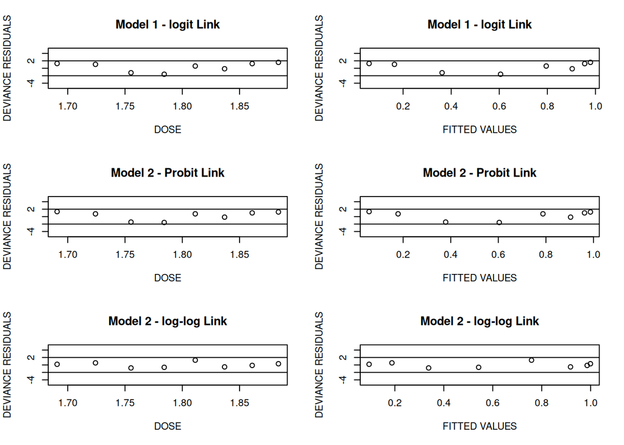

```r
# now plot the deviance residuals by dose and fitted values
par(mfrow=c(3,2))
plot(bioassay$dose,rd1,ylim=c(-5,5),xlab="DOSE",ylab="DEVIANCE RESIDUALS")
abline(h=-2)
abline(h=2)
title('Model 1 - logit Link')

plot(fv1,rd1,ylim=c(-5,5),xlab="FITTED VALUES",ylab="DEVIANCE RESIDUALS")
abline(h=-2)
abline(h=2)
title('Model 1 - logit Link')


plot(bioassay$dose,rd2,ylim=c(-5,5),xlab="DOSE",ylab="DEVIANCE RESIDUALS")
abline(h=-2)
abline(h=2)
title('Model 2 - Probit Link')

plot(fv2,rd2,ylim=c(-5,5),xlab="FITTED VALUES",ylab="DEVIANCE RESIDUALS")
abline(h=-2)
abline(h=2)
title('Model 2 - Probit Link')

plot(bioassay$dose,rd3,ylim=c(-5,5),xlab="DOSE",ylab="DEVIANCE RESIDUALS")
abline(h=-2)
abline(h=2)
title('Model 2 - log-log Link')

plot(fv3,rd3,ylim=c(-5,5),xlab="FITTED VALUES",ylab="DEVIANCE RESIDUALS")
abline(h=-2)
abline(h=2)
title('Model 2 - log-log Link')
```

All the residuals seem good, though they do all seem to have a dip in the same place. complimentary log-log has the least dip. They all look reasonable, though log-log does look the best. Lets try plotting the fitted models with the real data.

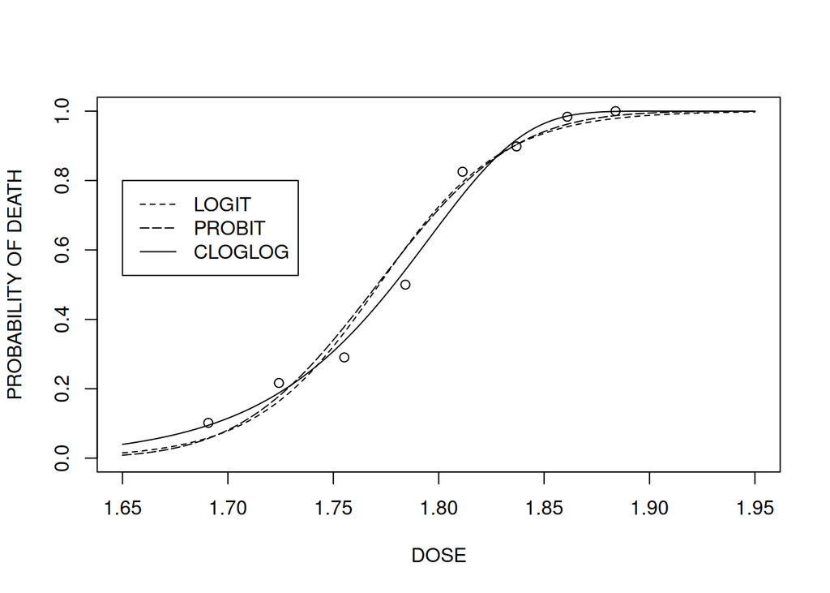

```r
plot(bioassay$dose,bioassay$y/bioassay$m,xlim=c(1.65,1.95), ylim=c(0,1),xlab='DOSE',ylab='PROBABILITY OF DEATH')

# create points to put into equation to make the line
x<-seq(1.65,1.95,by=0.001)
prob<-as.vector(rep(1,301))

beta<-as.vector(model1$coefficients) #extracting the coefficients
prob<-exp(beta[1]+beta[2]*x)/(1+exp(beta[1]+beta[2]*x)) # multiply created points by coefficients to get probability
lines(x,prob,lty=2)

beta<-as.vector(model2$coefficients)
prob<-pnorm(beta[1]+beta[2]*x)
lines(x,prob,lty=5)

beta<-as.vector(model3$coefficients)
prob<-1-exp(-exp(beta[1]+beta[2]*x))
lines(x,prob,lty=1)

legend(x=1.65,y=0.8,c("LOGIT","PROBIT","CLOGLOG"),lty=c(2,5,1))
```

All of them do look quite similar, though the C-log-log function does fit better in the center around 1.75-1.8, where that dip was in the residuals. This means we can write the model as:
$$log(-log(1-\pi_i))=\beta_0+\beta_1DOSE_i$$
to get the LD50, we substitute in $\pi=0.5$, and solve for dose,
$$DOSE=LD_{50}=\frac{log(-log(1-0.5))-\beta_0}{\beta_1}$$

Now lets get our confidence interval:

```r
beta<-as.vector(model3$coefficients)
V<-vcov(model3)
gradf<-c(-1/beta[2],(-log(-log(0.5))+beta[1])/(beta[2]^2))
SE.XLD50<-sqrt(t(gradf)%*%V%*%gradf)
XLD50<-(log(-log(0.5))-beta[1])/(beta[2])
XLD50
```

```
## [1] 1.778753
```

```r
XLD50.CI<-c(XLD50-1.96*SE.XLD50,XLD50+1.96*SE.XLD50)
XLD50.CI
```

```
## [1] 1.770900 1.786606
```